# Evaluating Lipoprotein(a) and ASCVD Risk Scores in Cardiovascular Outcomes

Slobodan Pantelić

2026-07-08

# Predicting Long-Term Cardiovascular Outcomes Using Clinical Risk Models

## Project Overview

Cardiovascular disease remains one of the leading causes of morbidity and mortality worldwide, making accurate risk prediction essential for guiding preventive treatment. Widely used clinical risk scores, such as the Atherosclerotic Cardiovascular Disease (ASCVD) risk estimator, provide estimates of an individual’s probability of experiencing a cardiovascular event over a specified time horizon. However, an important question is how well these predictions correspond to observed outcomes in real patient populations.

The objective of this project was to evaluate the predictive performance of established cardiovascular risk models using a real-world clinical dataset. In addition to assessing discrimination through logistic regression and receiver operating characteristic (ROC) analysis, the project investigates long-term event occurrence using survival analysis and compares observed patient outcomes with simulated survival curves derived from predicted risk estimates.

The analysis integrates several complementary statistical techniques, including data preprocessing and feature engineering, logistic regression modelling, ROC curve analysis, Kaplan–Meier survival analysis, hazard-rate simulation, and statistical comparison of observed and predicted outcomes. Alternative clinical scenarios, such as incorporating family history or modelling the effects of statin therapy, are also explored to examine how changes in patient characteristics influence predicted cardiovascular risk.

Rather than focusing solely on predictive accuracy, this project demonstrates an end-to-end analytical workflow typical of healthcare analytics and clinical research. The emphasis is placed on reproducible statistical analysis, clear visualization of results, and critical evaluation of model performance in a real-world setting.

### Analytical Workflow

1. Import and integrate patient-level clinical data from multiple sources.
2. Perform data cleaning, preprocessing, and feature engineering.
3. Estimate cardiovascular event risk using established clinical prediction models.
4. Evaluate model discrimination using logistic regression and ROC analysis.
5. Assess time-to-event outcomes using Kaplan–Meier survival analysis.
6. Simulate expected survival from predicted risks and compare simulated and observed event curves.
7. Explore alternative clinical scenarios and interpret findings within a cardiovascular risk prediction framework.

### Tools and Methods

- **Programming language:** R
- **Statistical methods:** Logistic regression, ROC analysis, Kaplan–Meier survival analysis, survival simulation, likelihood ratio testing
- **Key packages:** tidyverse, survival, survminer, pROC, ggplot2

# 1. Environment Setup & Data Ingestion

### Libraries

- `readxl`: Data ingestion.
- `tidyverse`: Data manipulation and visualization.
- `AUC`: Discrimination metrics (Sensitivity, Specificity, ROC, AUC).
- `survival` & `survminer`: Time-to-event analysis and Kaplan-Meier curves.

```r
library(readxl)
library(tidyverse)
library(AUC)
library(survival)
library(survminer)
```

### Data Sources

```r
LpA       <- read_excel("LpA.xlsx")
Imaging   <- read_excel("Imaging.xlsx")
Time_data <- read_excel("MI Data Expected vs. Observed.xlsx")
ROC_Data <- read_excel("ROC Data.xlsx")
```

# 2. ASCVD Risk Category & Lp(a) as Predictors of Imaging Findings

We first evaluate how well standard ASCVD risk categories (Low, Borderline, Intermediate, High) predict the presence of subclinical atherosclerosis on imaging, using the Intermediate category as our baseline reference.

### 2.1 Baseline Model: ASCVD Risk Category Alone

```r
Risk_model <- glm(
  Ath_imaging ~ ASCVD_low + ASCVD_borderline + ASCVD_high,
  data = LpA,
  family = "binomial"
)
summary(Risk_model)
```

```
##
## Call:
## glm(formula = Ath_imaging ~ ASCVD_low + ASCVD_borderline + ASCVD_high,
##     family = "binomial", data = LpA)
##
## Coefficients: (1 not defined because of singularities)
##                   Estimate Std. Error z value Pr(>|z|)
## (Intercept)         1.4663     0.6405   2.289   0.0221 *
## ASCVD_low          -1.4663     0.6584  -2.227   0.0259 *
## ASCVD_borderline   16.0997  1142.0511   0.014   0.9888
## ASCVD_high              NA         NA      NA       NA
## ---
## Signif. codes:  0 '***' 0.001 '**' 0.01 '*' 0.05 '.' 0.1 ' ' 1
##
## (Dispersion parameter for binomial family taken to be 1)
##
##     Null deviance: 274.83  on 199  degrees of freedom
## Residual deviance: 253.89  on 197  degrees of freedom
## AIC: 259.89
##
## Number of Fisher Scoring iterations: 16
```

### 2.2 Adding Lp(a) to the Baseline Model

```r
Risk_and_LpA_model <- glm(
  Ath_imaging ~ ASCVD_low + ASCVD_borderline + ASCVD_high + LpA,
  data = LpA,
  family = "binomial"
)
summary(Risk_and_LpA_model)
```

```
##
## Call:
## glm(formula = Ath_imaging ~ ASCVD_low + ASCVD_borderline + ASCVD_high +
##     LpA, family = "binomial", data = LpA)
##
## Coefficients: (1 not defined because of singularities)
##                    Estimate Std. Error z value Pr(>|z|)
## (Intercept)         1.51111    0.65856   2.295   0.0218 *
## ASCVD_low          -1.46438    0.65853  -2.224   0.0262 *
## ASCVD_borderline   16.08459 1141.65945   0.014   0.9888
## ASCVD_high               NA         NA      NA       NA
## LpA                -0.08833    0.29726  -0.297   0.7663
## ---
## Signif. codes:  0 '***' 0.001 '**' 0.01 '*' 0.05 '.' 0.1 ' ' 1
##
## (Dispersion parameter for binomial family taken to be 1)
##
##     Null deviance: 274.83  on 199  degrees of freedom
## Residual deviance: 253.80  on 196  degrees of freedom
## AIC: 261.8
##
## Number of Fisher Scoring iterations: 16
```

**Interpretation:** Adding Lp(a) to the model does not significantly improve predictive power for imaging findings (p = 0.766). Furthermore, the Akaike Information Criterion (AIC) slightly increased from 259.89 in the baseline model to 261.80 here. This indicates that the simpler model without Lp(a) is statistically preferred for this specific dataset.

### 2.3 Model Cross-Validation in the Imaging Cohort

```r
Risk_imaging_model <- glm(
  Ath_imaging ~ ASCVD_low + ASCVD_borderline + ASCVD_high,
  data = Imaging,
  family = "binomial"
)

Imaging$Predicted <- Risk_imaging_model$fitted.values
Imaging <- Imaging %>%
  mutate(Predicted_binary = ifelse(Predicted > 0.51, 1, 0))

# Confusion matrix: Predicted vs. Actual imaging finding
table(Predicted = Imaging$Predicted_binary, Actual = Imaging$Ath_imaging)
```

```
##          Actual
## Predicted   0   1
##         0 550 378
##         1  41 111
```

### 2.4 Cohort Baseline Statistics

```r
Imaging$Risk <- as.numeric(Imaging$Risk)
Imaging <- Imaging %>% filter(!is.na(Risk))

cat("Mean ASCVD Risk: ", mean(Imaging$Risk), "\n")
```

```
## Mean ASCVD Risk:  2.575904
```

```r
cat("Standard Deviation: ", sd(Imaging$Risk), "\n")
```

```
## Standard Deviation:  2.397945
```

```r
cat("Imaging Finding Prevalence: ", mean(Imaging$Ath_imaging), "\n")
```

```
## Imaging Finding Prevalence:  0.4522706
```

# 3. Discrimination Analysis (ROC & AUC)

We utilize the `AUC` package to compare the standalone discriminatory power of Lp(a) versus the continuous 10-year ASCVD risk score.

### 3.1 Lp(a) Alone

```r
rocLpA <- roc(as.factor(LpA$LpA), as.factor(LpA$Ath_imaging))
cat("Lp(a) AUC: ", auc(rocLpA), "\n")
```

```
## Lp(a) AUC:  0.4780848
```

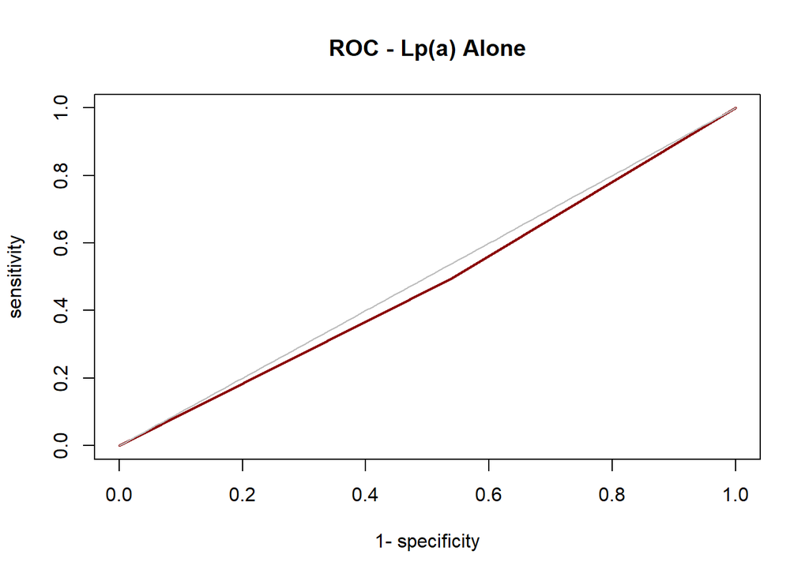

```r
plot(rocLpA, type = "l", main = "ROC - Lp(a) Alone", col = "darkred", lwd = 2)
```

**Interpretation:** Lp(a) performs poorly as an independent binary classifier for subclinical atherosclerosis. It yields an AUC of 0.478, which is essentially equivalent to random guessing (AUC = 0.50).

### 3.2 Continuous ASCVD Risk Score Alone

```r
rocASCVD <- roc(Imaging$Risk, as.factor(Imaging$Ath_imaging))
cat("ASCVD Risk AUC: ", auc(rocASCVD), "\n")
```

```
## ASCVD Risk AUC:  0.7130801
```

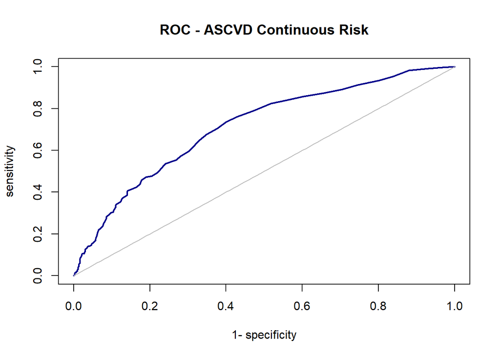

```r
plot(rocASCVD, main = "ROC - ASCVD Continuous Risk", col = "darkblue", lwd = 2)
```

**Interpretation:** In contrast to Lp(a), the continuous ASCVD risk score demonstrates acceptable discrimination with an AUC of 0.713. It serves as a significantly better standalone predictor for positive imaging findings in this cohort.

# 4. Survival Analysis: Time to Revascularization (CABG/PCI)

This section evaluates actual clinical outcomes over a 7-year follow-up period.

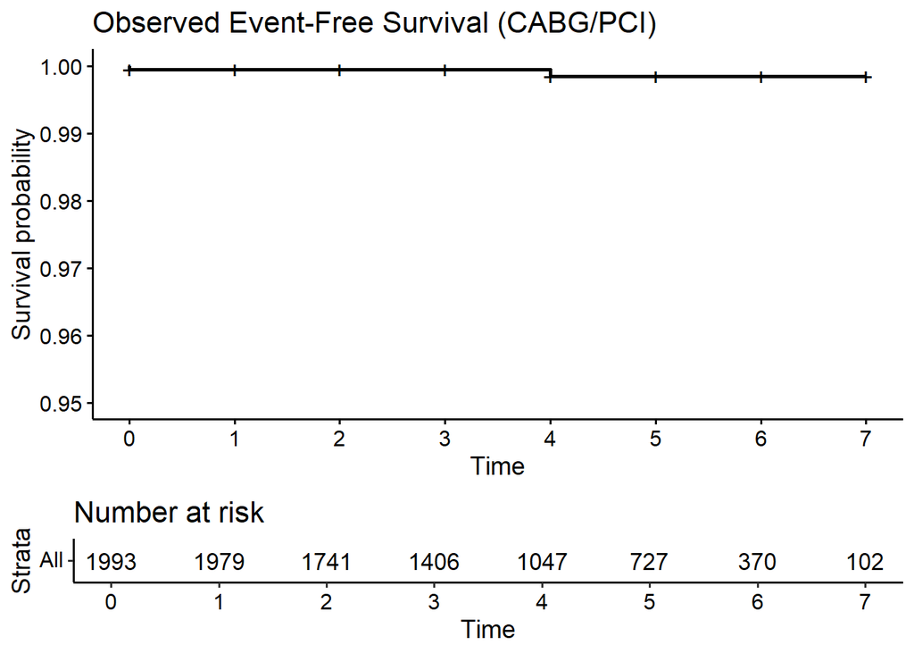

```r
Time_data <- Time_data %>%
  mutate(`CABG/PCI` = ifelse(is.na(`CABG/PCI`), 0, `CABG/PCI`))

km_fit <- survfit(Surv(`Folow up in years`, `CABG/PCI`) ~ 1, data = Time_data)

km_plot_observed <- ggsurvplot(
  km_fit,
  times = c(1:7),
  ylim = c(0.95, 1),
  xlim = c(0, 7),
  risk.table = TRUE,
  break.time.by = 1,
  conf.int = FALSE,
  legend = "none",
  title = "Observed Event-Free Survival (CABG/PCI)",
  palette = "black"
)
km_plot_observed
```

**Interpretation:** The observed data shows an exceptionally high event-free survival rate, remaining at 99.9% over the 7-year follow-up. Only 2 hard clinical events (CABG/PCI) were recorded across nearly 2,000 baseline patients, indicating a very low-risk cohort overall.

# 5. Simulating “Predicted” Survival from ASCVD Scores

To test calibration, we convert each patient’s 10-year ASCVD risk into an implied 7-year risk (assuming a constant hazard rate) and simulate expected clinical events.

```r
# Derive 7-year risk and constant hazard rate
Time_data$seven_year_risk <- 1 - (1 - (Time_data$`ASCVD 10-Year`/100))^(7/10)
Time_data$hazard_rate     <- -log(1 - Time_data$seven_year_risk) / 7

# Simulate events
set.seed(123)
Time_data$simulated_event_times <- rexp(nrow(Time_data), rate = Time_data$hazard_rate)
Time_data$simulated_event       <- ifelse(Time_data$simulated_event_times <= Time_data$`Folow up in years`, 1, 0)
Time_data$observed_times        <- pmin(Time_data$simulated_event_times, Time_data$`Folow up in years`)
```

### 5.1 Observed vs. Simulated Comparison

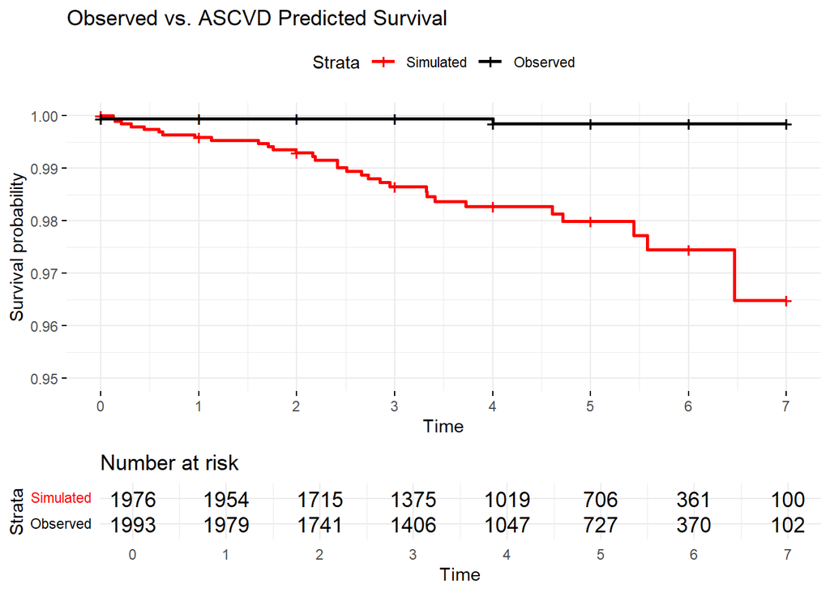

```r
Combined_full_data <- bind_rows(
  tibble(Follow_up = Time_data$`Folow up in years`, Event = Time_data$`CABG/PCI`, Data = "Observed"),
  tibble(Follow_up = Time_data$observed_times, Event = Time_data$simulated_event, Data = "ASCVD Predicted")
) %>%
  mutate(Data = factor(Data, levels = c("ASCVD Predicted", "Observed")))

km_full_fit <- survfit(Surv(Follow_up, Event) ~ Data, data = Combined_full_data)

ggsurvplot(
  km_full_fit,
  ylim = c(0.95, 1),
  xlim = c(0, 7),
  risk.table = TRUE,
  break.time.by = 1,
  conf.int = FALSE,
  legend.labs = c("Simulated", "Observed"),
  ggtheme = theme_minimal(),
  palette = c("red", "black"),
  title = "Observed vs. ASCVD Predicted Survival"
)
```

# 6. Scenario Modeling: Family History & Statins

We simulate how clinical interventions (statins) or genetic risk modifiers (family history) affect expected outcomes.

```r
Data_Additional <- read_excel("Data Additional .xlsx")

full_data <- inner_join(Data_Additional, Time_data, by = "Original Number") %>%
  rename_with(~str_replace(., "\\.x$", ""), ends_with(".x")) %>%
  select(-ends_with(".y"))

# Scenario 1: Family History
full_data$seven_year_risk_x2 <- 1 - (1 - (full_data$`ASCVD 10-Year x2`/100))^(7/10)
full_data$hazard_rate_x2     <- -log(1 - full_data$seven_year_risk_x2) / 7
set.seed(123)
full_data$simulated_event_times_x2 <- rexp(nrow(full_data), rate = full_data$hazard_rate_x2)
full_data$simulated_event_x2       <- ifelse(full_data$simulated_event_times_x2 <= full_data$`Folow up in years`, 1, 0)
full_data$observed_times_x2        <- pmin(full_data$simulated_event_times_x2, full_data$`Folow up in years`)

# Scenario 2: Statin Therapy
full_data$seven_year_risk_statins <- 1 - (1 - (full_data$`ASCVD Statin`/100))^(7/10)
full_data$hazard_rate_statins     <- -log(1 - full_data$seven_year_risk_statins) / 7
set.seed(123)
full_data$simulated_event_times_statins <- rexp(nrow(full_data), rate = full_data$hazard_rate_statins)
full_data$simulated_event_statins       <- ifelse(full_data$simulated_event_times_statins <= full_data$`Folow up in years`, 1, 0)
full_data$observed_times_statins        <- pmin(full_data$simulated_event_times_statins, full_data$`Folow up in years`)
```

### 6.1 Four-Way Scenario Comparison

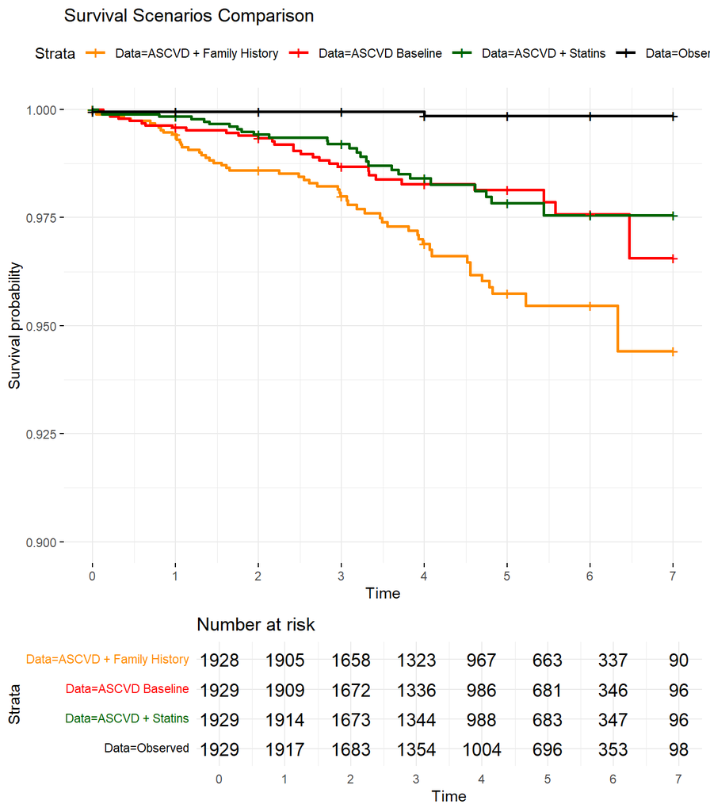

```r
Combined_full_data_2 <- bind_rows(
  tibble(Follow_up = full_data$`Folow up in years`, Event = full_data$`CABG/PCI`, Data = "Observed"),
  tibble(Follow_up = full_data$observed_times, Event = full_data$simulated_event, Data = "ASCVD Baseline"),
  tibble(Follow_up = full_data$observed_times_x2, Event = full_data$simulated_event_x2, Data = "ASCVD + Family History"),
  tibble(Follow_up = full_data$observed_times_statins, Event = full_data$simulated_event_statins, Data = "ASCVD + Statins")
) %>%
  mutate(Data = factor(Data, levels = c("ASCVD + Family History", "ASCVD Baseline", "ASCVD + Statins", "Observed")))

km_full_fit_4group <- survfit(Surv(Follow_up, Event) ~ Data, data = Combined_full_data_2)

km_plot_four_group <- ggsurvplot(
  km_full_fit_4group,
  ylim = c(0.9, 1),
  xlim = c(0, 7),
  risk.table = TRUE,
  break.time.by = 1,
  conf.int = FALSE,
  ggtheme = theme_minimal(),
  palette = c("darkorange", "red", "darkgreen", "black"),
  title = "Survival Scenarios Comparison"
)
km_plot_four_group
```

**Interpretation:** Applying a family history multiplier pulls the predicted survival curve down (higher risk), while statin therapy pushes it slightly upward (protective). However, because the absolute baseline risk is fundamentally minimal, the absolute separation between these curves over a 7-year horizon remains visually marginal.

# 7. Predicting Atherosclerosis (AS)

Lp(a) is a well-established causal risk factor for calcific aortic valve disease. Here, we test if it adds predictive power for AS specifically.

```r
Logistic_ASCVD_only <- glm(AS ~ `ASCVD 10-Year`, family = "binomial", data = ROC_Data)
Logistic_ASCVD_LpA  <- glm(AS ~ `ASCVD 10-Year` + LpA, family = "binomial", data = ROC_Data)

anova(Logistic_ASCVD_LpA, Logistic_ASCVD_only)
```

```
## Analysis of Deviance Table
##
## Model 1: AS ~ `ASCVD 10-Year` + LpA
## Model 2: AS ~ `ASCVD 10-Year`
##   Resid. Df Resid. Dev Df   Deviance
## 1       732     876.08
## 2       733     876.08 -1 -0.0028961
```

```r
cat("AIC ASCVD Only: ", AIC(Logistic_ASCVD_only), "\n")
```

```
## AIC ASCVD Only:  880.0823
```

```r
cat("AIC ASCVD + LpA: ", AIC(Logistic_ASCVD_LpA), "\n")
```

```
## AIC ASCVD + LpA:  882.0794
```

Interpretation: Comparing the models reveals that adding Lp(a) does not improve predictive power for Atherosclerosis. The Analysis of Deviance shows a practically unchanged residual deviance (-0.0028 difference), and the Akaike Information Criterion (AIC) actually increases from 880.08 (ASCVD alone) to 882.08 (ASCVD + Lp(a)). This indicates that the simpler ASCVD-only model is statistically preferred, and Lp(a) fails to provide additive predictive value for valve calcification in this dataset.

### 7.1 ROC Comparison Plot

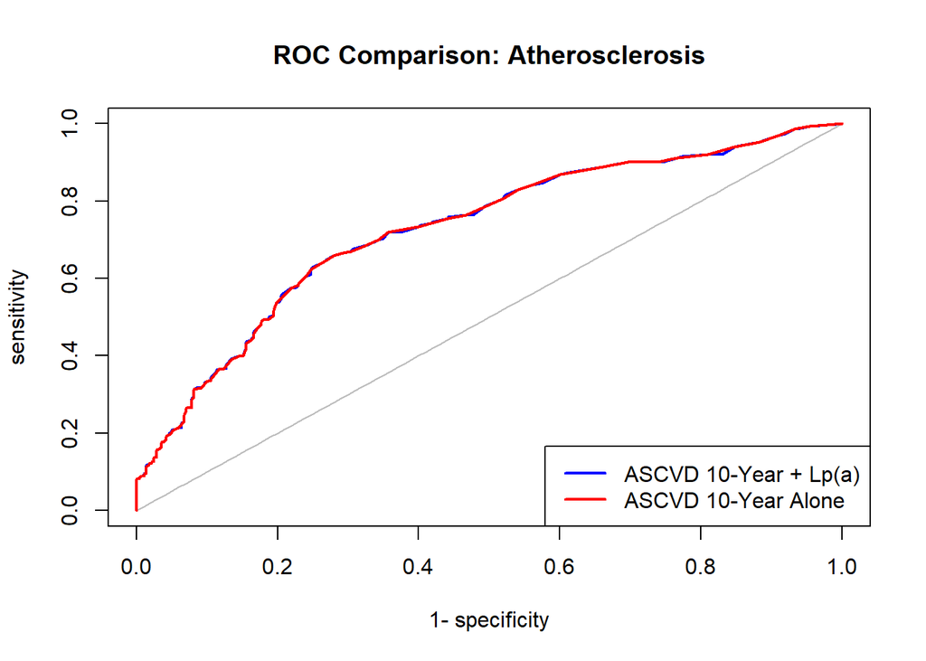

```r
ROC_Data$ASCVD_LpA <- Logistic_ASCVD_LpA$fitted.values

rocASCVD_AS     <- roc(ROC_Data$`ASCVD 10-Year`, as.factor(ROC_Data$AS))
rocASCVD_LpA_AS <- roc(ROC_Data$ASCVD_LpA, as.factor(ROC_Data$AS))

plot(rocASCVD_LpA_AS, col = "blue", main = "ROC Comparison: Atherosclerosis", lwd = 2)
plot(rocASCVD_AS, col = "red", add = TRUE, lwd = 2)
legend(
  "bottomright",
  legend = c("ASCVD 10-Year + Lp(a)", "ASCVD 10-Year Alone"),
  col = c("blue", "red"),
  lwd = 2
)
```

Interpretation: The visually overlapping ROC curves confirm the statistical findings. The addition of Lp(a) (blue line) to the 10-year ASCVD score (red line) yields virtually identical discrimination for Atherosclerosis, emphasizing that Lp(a) does not meaningfully enhance the model’s predictive performance.

# 8. Project Conclusion

Based on this analysis, Lp(a) does not significantly improve discrimination for subclinical atherosclerosis over the standard ASCVD 10-year risk score in this specific cohort. The ASCVD risk score alone proved to be a capable predictor (AUC = 0.713), whereas Lp(a) levels operated near random chance.

Furthermore, the cohort evaluated here is an extremely low-risk population, showing a 99.9% event-free survival rate over 7 years. Because of this floor effect, the mathematical introduction of statins or family history variables results in negligible absolute shifts in 7-year event forecasts.

Finally, extending the analysis to Atherosclerosis (Section 7) revealed that Lp(a) also failed to provide any additive predictive value for calcific valve pathogenesis. The AIC increased when Lp(a) was added to the ASCVD baseline model, and the ROC curves remained practically identical. Ultimately, in this exceptionally low-risk dataset, standard ASCVD risk assessments fully capture the available predictive signal without requiring supplemental Lp(a) measurements.